# Detecting Cointegrating Relations in Non-Stationary Matrix-Valued Time Series

CFE-CM Statistics

Ivan Ricardo

Maastricht University

Alain Hecq

Maastricht University

Ines Wilms

Maastricht University

December 15, 2025

## Stacked Data Structures

#### Univariate $(y_t)$

$$\begin{bmatrix}
\bullet \\
\bullet \\
\bullet
\end{bmatrix}$$

#### Multivariate $(\mathbf{y}_t)$

$$\begin{bmatrix}
\bullet & \bullet & \bullet \\
\bullet & \bullet & \bullet \\
\bullet & \bullet & \bullet
\end{bmatrix}$$

#### Matrix-valued $(\mathbf{Y}_t)$

[figure not shown]

Examples of matrix-valued data:

- Economic indicators for different countries over time
- Different air pollutants for cities over time (Yuan et al. 2023)
- Employment data over different sectors for different U.S. States over time (Samadi and Billard 2024)

## Our Setting

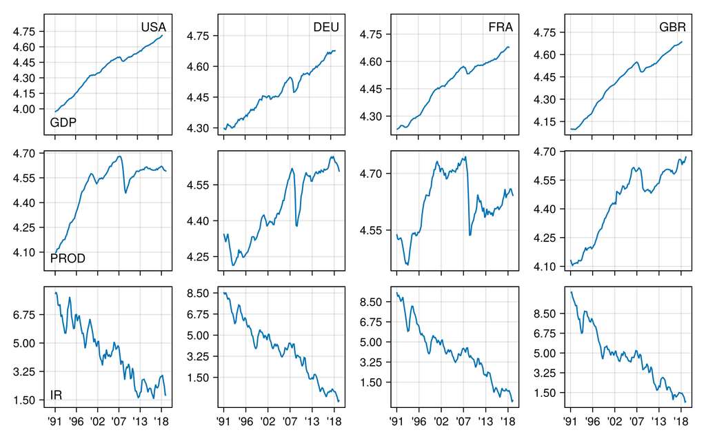

- We have $N_1 = 3$ economic indicators (GDP, Industrial Production, Interest Rates) over $N_2 = 4$ countries (USA, DEU, FRA, GBR)
- We are interested in whether there exists cointegrating relations for the economic indicators and the countries **separately**

## Why Matrix-valued data?

- “Flattening” loses **dimension-specific interpretations**
- **Flexibility** in reduced-rank structures
- Allows for more **parsimonious models**

### Main Contributions:

- Distinguish cointegration relations along the dimensions of the matrix-valued time series.
- Utilize information criteria to determine row and column cointegration ranks
- Validate rank selection with Monte Carlo simulations and macroeconomic application

# From Vector to Matrix Valued Time Series

## VECM for multivariate/vector-valued time series

In the presence of cointegration, the stacked VECM is

$$\boldsymbol{\Delta} \mathbf{y}_t = \mathbf{d} + \boldsymbol{\alpha} \boldsymbol{\beta}'\mathbf{y}_{t-1} + \sum_{j=1}^{p-1} \boldsymbol{\phi}_j \boldsymbol{\Delta} \mathbf{y}_{t-j} + \mathbf{e}_t$$

- $\mathbf{d} \in \mathbb{R}^{N}$ is the deterministic term
- $\boldsymbol{\beta} \in \mathbb{R}^{N \times r}$ is the cointegrating matrix for the economic indicators and countries
- $\boldsymbol{\alpha} \in \mathbb{R}^{N \times r}$ is the corresponding adjustment coefficient matrix
- $\boldsymbol{\phi}_j \in \mathbb{R}^{N \times N}$ is the autoregressive coefficient matrix

## Matrix Error Correction Model

The Error Correction Model with matrix-valued observations is
$$\boldsymbol{\Delta} \mathbf{Y}_t = \mathbf{D} + \mathbf{U}_1 \mathbf{U}_3'\mathbf{Y}_{t-1} \mathbf{U}_4 \mathbf{U}_2' + \sum_{j=1}^{p-1} \boldsymbol{\phi}_{1,j} \boldsymbol{\Delta} \mathbf{y}_{t-j} \boldsymbol{\phi}_{2,j}' + \mathbf{E}_t$$

$$\mathbf{E}_t \sim MVN(\mathbf{0}, \boldsymbol{\Sigma}_1, \boldsymbol{\Sigma}_2)$$

- $\mathbf{U}_3 \in \mathbb{R}^{N_1 \times r_1}$ and $\mathbf{U}_4 \in \mathbb{R}^{N_2 \times r_2}$ are the cointegrating matrices for the rows (economic indicators) and columns (countries)
- $\mathbf{U}_1 \in \mathbb{R}^{N_1 \times r_1}$ and $\mathbf{U}_2 \in \mathbb{R}^{N_2 \times r_2}$ are the adjustment coefficients
- $\boldsymbol{\phi}_1 \in \mathbb{R}^{N_1 \times N_1}$ and $\boldsymbol{\phi}_2 \in \mathbb{R}^{N_2 \times N_2}$ are the matrix AR coefficients.

## Matrix Error Correction Model restrictions

Vectorizing the MECM<sup>1</sup> yields
$$\boldsymbol{\Delta} \mathbf{y}_t = \mathbf{d} + \underbrace{(\mathbf{U}_2 \otimes \mathbf{U}_1)}_{\boldsymbol{\alpha}} \underbrace{(\mathbf{U}_4 \otimes \mathbf{U}_3)'}_{\boldsymbol{\beta}'} \mathbf{y}_{t-1} + \sum_{j=1}^{p-1} \underbrace{(\boldsymbol{\phi}_{2,j} \otimes \boldsymbol{\phi}_{1,j})}_{\boldsymbol{\phi}_j} \boldsymbol{\Delta} \mathbf{y}_{t-j} + \mathbf{e}_t$$
$$\operatorname{vec}(\mathbf{E}_t) \sim N(\operatorname{vec}(\mathbf{0}), \boldsymbol{\Sigma}_2 \otimes \boldsymbol{\Sigma}_1)$$

- This form has been proposed by Li and Xiao (2024)
- We complement their study by allowing for different numbers of cointegrating relations and different lag orders
[^1]: Using the identity $\operatorname{vec}(\mathbf{A} \mathbf{X} \mathbf{B}) = (\mathbf{B}' \otimes \mathbf{A})\operatorname{vec}(\mathbf{X})$

# Estimation and Selection of Cointegrating Ranks

## Log-Likelihood

The log-likelihood (up to a constant) of the MECM(p) for fixed rank $r_1$ and $r_2$ is
$$\mathcal{L} (\boldsymbol{\Theta}) = -\frac{T N_2}{2} \log | \boldsymbol{\Sigma}_1 | - \frac{T N_1}{2} \log | \boldsymbol{\Sigma}_2 | - \frac{1}{2} \sum_{t=1}^T \operatorname{tr} \left(\boldsymbol{\Sigma}_1^{-1} \mathbf{E}_t \boldsymbol{\Sigma}_2^{-1} \mathbf{E}_t'\right)$$
where $\mathbf{E}_t = \boldsymbol{\Delta} \mathbf{Y}_t - \mathbf{U}_1 \mathbf{U}_3' \mathbf{Y}_{t-1} \mathbf{U}_4 \mathbf{U}_2' - \sum_{j=1}^{p-1} \boldsymbol{\phi}_{1,j} \boldsymbol{\Delta} \mathbf{Y}_{t-j} \boldsymbol{\phi}_{2,j}' - \mathbf{D}$ and $\boldsymbol{\Theta}$ collects all parameters. This can be solved using *gradient descent*.

Algorithm Details

## Selection of Cointegration ranks

In practice, the ranks $r_1$ and $r_2$ are unknown and must be selected. We use Akaike Information Criteria (AIC) and Bayesian Information Criteria (BIC).
$$\text{AIC}(r_1, r_2, p) = -2 \mathcal{L}(\widehat{\boldsymbol{\Theta}}) + 2 \psi(r_1, r_2, p) \\
\text{BIC}(r_1, r_2, p) = -2 \mathcal{L}(\widehat{\boldsymbol{\Theta}}) + \ln(T) \psi(r_1, r_2, p)$$

where
$$\psi(r_1, r_2, p) = r_1 (2 N_1 - r_1) + r_2 (2 N_2 - r_2) + (p-1) (N_1^2 + N_2^2)$$
is the number of parameters to estimate.

# Simulation Study

## First Simulation Study

- Selecting ranks with AIC and BIC
- DGP is the MECM with 0 lags

| Setting |  |  | $N_1 \times N_2 = 3 \times 4$ |
| --- | --- | --- | --- |
| Fully Reduced |  |  | $\mathbf{r} = (1,1)$ |
| Partially Reduced (1st Dimension) |  |  | $\mathbf{r} = (1,4)$ |
| Partially Reduced (2nd Dimension) |  |  | $\mathbf{r} = (3,1)$ |
| No Rank Reduction |  |  | $\mathbf{r} = (3,4)$ |

## Fully reduced

### True rank of $\mathbf{r} = (1,1)$

[output not shown]

[^2]: Defined as the information criteria and number of observations (either 100 or 250)

## Reduced Rank in First Dimension

### True rank of $\mathbf{r} = (1,4)$

| Method | Average Rank | Standard Deviation | Freq. Correct |
| --- | --- | --- | --- |
| AIC (100) | (1.13, 3.99) | (0.34, 0.03) | (0.87, 0.99) |
| BIC (100) | (1.06, 3.99) | (0.24, 0.03) | (0.94, 0.99) |
| AIC (250) | (1.03, 4.00) | (0.18, 0.00) | (0.97, 1.00) |
| BIC (250) | (1.02, 4.00) | (0.14, 0.00) | (0.98, 1.00) |

## Reduced Rank in Second Dimension

### True rank of $\mathbf{r} = (3,1)$

| Method | Average Rank | Standard Deviation | Freq. Correct |
| --- | --- | --- | --- |
| AIC (100) | (3.00, 1.07) | (0.00, 0.26) | (1.00, 0.93) |
| BIC (100) | (3.00, 1.01) | (0.00, 0.04) | (1.00, 0.99) |
| AIC (250) | (3.00, 1.03) | (0.00, 0.17) | (1.00, 0.97) |
| BIC (250) | (3.00, 1.00) | (0.00, 0.00) | (1.00, 1.00) |

## No rank reduction

### True rank of $\mathbf{r} = (3,4)$

| Method | Average Rank | Standard Deviation | Freq. Correct |
| --- | --- | --- | --- |
| AIC (100) | (3.00, 4.00) | (0.00, 0.00) | (1.00, 1.00) |
| BIC (100) | (3.00, 4.00) | (0.00, 0.00) | (1.00, 1.00) |
| AIC (250) | (3.00, 4.00) | (0.00, 0.00) | (1.00, 1.00) |
| BIC (250) | (3.00, 4.00) | (0.00, 0.00) | (1.00, 1.00) |

## Second Simulation Study

- DGP is the MECM with 1 lag

| Setting |  |  | $N_1 \times N_2 = 3 \times 4$ |
| --- | --- | --- | --- |
| Fully Reduced |  |  | $\mathbf{r} = (1,1)$ |
| Partially Reduced (1st Dimension) |  |  | $\mathbf{r} = (1,4)$ |
| Partially Reduced (2nd Dimension) |  |  | $\mathbf{r} = (3,1)$ |
| No Rank Reduction |  |  | $\mathbf{r} = (3,4)$ |

## Fully reduced

### True rank of $\mathbf{r} = (1,1)$

| Method | Average Rank | Standard Deviation | Freq. Correct |
| --- | --- | --- | --- |
| AIC (100) | (1.06, 1.03) | (0.23, 0.21) | (0.94, 0.97) |
| BIC (100) | (1.01, 1.00) | (0.08, 0.00) | (0.99, 1.00) |
| AIC (250) | (1.06, 1.02) | (0.23, 0.15) | (0.94, 0.98) |
| BIC (250) | (1.01, 1.00) | (0.08, 0.00) | (0.99, 1.00) |

## Reduced Rank in First Dimension

### True rank of $\mathbf{r} = (1,4)$

| Method | Average Rank | Standard Deviation | Freq. Correct |
| --- | --- | --- | --- |
| AIC (100) | (1.01, 4.00) | (0.05, 0.00) | (0.99, 1.00) |
| BIC (100) | (1.01, 4.00) | (0.03, 0.00) | (0.99, 1.00) |
| AIC (250) | (1.00, 4.00) | (0.00, 0.00) | (1.00, 1.00) |
| BIC (250) | (1.00, 4.00) | (0.00, 0.00) | (1.00, 1.00) |

## Reduced Rank in Second Dimension

### True rank of $\mathbf{r} = (3,1)$

| Method | Average Rank | Standard Deviation | Freq. Correct |
| --- | --- | --- | --- |
| AIC (100) | (3.00, 1.23) | (0.00, 0.59) | (1.00, 0.86) |
| BIC (100) | (3.00, 1.01) | (0.00, 0.08) | (1.00, 0.99) |
| AIC (250) | (3.00, 1.10) | (0.00, 0.40) | (1.00, 0.93) |
| BIC (250) | (3.00, 1.01) | (0.00, 0.03) | (1.00, 0.99) |

## No rank reduction

### True rank of $\mathbf{r} = (3,4)$

| Method | Average Rank | Standard Deviation | Freq. Correct |
| --- | --- | --- | --- |
| AIC (100) | (3.00, 4.00) | (0.00, 0.00) | (1.00, 1.00) |
| BIC (100) | (3.00, 4.00) | (0.00, 0.00) | (1.00, 1.00) |
| AIC (250) | (3.00, 4.00) | (0.00, 0.00) | (1.00, 1.00) |
| BIC (250) | (3.00, 4.00) | (0.00, 0.00) | (1.00, 1.00) |

# Empirical Application

## Macroeconomic Indicators for various countries

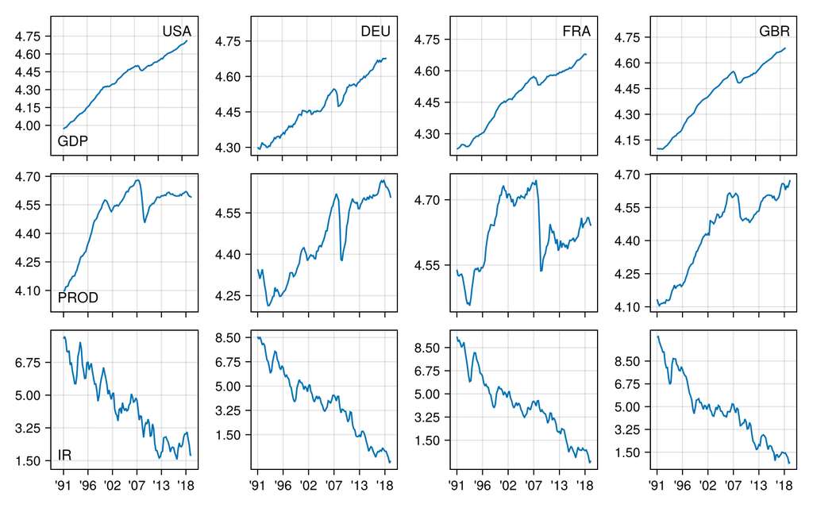

- We take log of real GDP, PROD, levels of long-term interest rates
- AIC and BIC select a rank of $(1,1)$ with one lag
- One cointegrating relation between the countries and economic indicators

## Estimated Coefficient Values

### Row-wise coefficients

| Indicator | $\widehat{\mathbf{U}}_1$ | $\widehat{\mathbf{U}}_3$ |
| --- | --- | --- |
| GDP | -0.084 | 1.000 |
| PROD | -0.201 | -0.099 |
| IR | -7.843 | -0.021 |

### Column-wise coefficients

| Country | $\widehat{\mathbf{U}}_2$ | $\widehat{\mathbf{U}}_4$ |
| --- | --- | --- |
| USA | 0.088 | 1.000 |
| DEU | 0.774 | 0.055 |
| FRA | 1.103 | -1.092 |
| GBR | 0.674 | -0.196 |

- Each $\widehat{\mathbf{U}}_1$ and $\widehat{\mathbf{U}}_2$ entry shows how strongly a row (indicator) or column (country) responds to deviations from the long-run equilibrium
- $\widehat{\mathbf{U}}_3$ (indicators) and $\widehat{\mathbf{U}}_4$ (countries) capture the linear combination of variables that form the long-run equilibrium

## Cointegrating relation

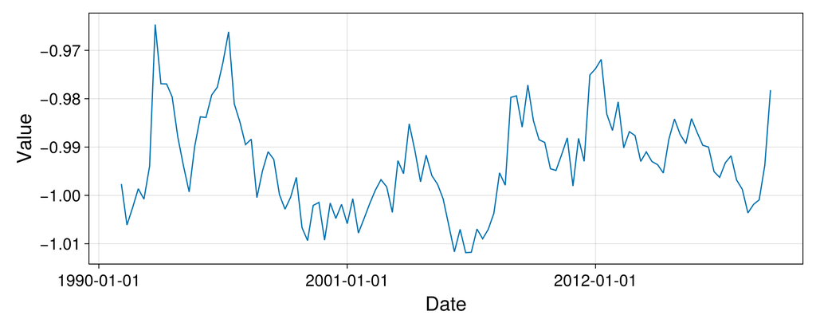

- The cointegrated series $(\widehat{\mathbf{U}}_4 \otimes \widehat{\mathbf{U}}_3)' \operatorname{vec}(\mathbf{Y}_{t-1})$ shows two spikes at the beginning of the 90s but stays stable around the mean value of -0.99

# Conclusion

## Conclusion

- Investigated the matrix error-correction model for cointegration separately across row and column dimensions of matrix time series
- Proposed AIC/BIC for joint rank and lag selection and showed finite sample performance across simulation settings
- Applied the approach to international macroeconomic indicators, finding one stable long-run relation across both indicators and countries

### Link to Paper

[figure not shown]

### Github

## References

Li, Zebang, and Han Xiao. 2024. “Cointegrated Matrix Autoregression Models.” *arXiv Preprint arXiv:2409.10860*.

Samadi, S. Yaser, and Lynne Billard. 2024. “On a Matrix-Valued Autoregressive Model.” *Journal of Time Series Analysis*. https://onlinelibrary.wiley.com/doi/abs/10.1111/jtsa.12748.

Van Loan, Charles F. 2000. “The Ubiquitous Kronecker Product.” *Journal of Computational and Applied Mathematics* 123 (1-2): 85–100.

Yuan, Chaofeng, Zhigen Gao, Xuming He, Wei Huang, and Jianhua Guo. 2023. “Two-way dynamic factor models for high-dimensional matrix-valued time series.” *Journal of the Royal Statistical Society Series B: Statistical Methodology* 85 (5): 1517–37. https://doi.org/10.1093/jrsssb/qkad077.

## Appendix

Pseudo-Code for the Gradient Descent Algorithm

- Initialize parameters using Nearest Kronecker Product (Van Loan 2000)
- Cycle through parameter blocks (block coordinate updates): $\mathbf{D}, \mathbf{U}_1, \mathbf{U}_2, \mathbf{U}_3, \mathbf{U}_4, \boldsymbol{\Sigma}_1, \boldsymbol{\Sigma}_2, \boldsymbol{\phi}_1, \boldsymbol{\phi}_2$
- Each block is updated by taking a step in the negative gradient direction with its own step size (calculated using the Lipschitz constant)
- Certain matrices are renormalized after each update
- Continue until loss improvement falls below the tolerance threshold

Back to main